# Внешний курс. Блок 1 - Безопасность в сети

Основы кибербезопасности

Ефремова Полина Александровна

1132246726@rudn.ru

Российский университет дружбы народов

2026-05-16

# Информация

## Докладчик

- Ефремова Полина Александровна
- бакалавр
- Российский университет дружбы народов
- 1132246726@rudn.ru
- Доклад по теме: Внешний курс Stepik: “Основы кибербезопасности”

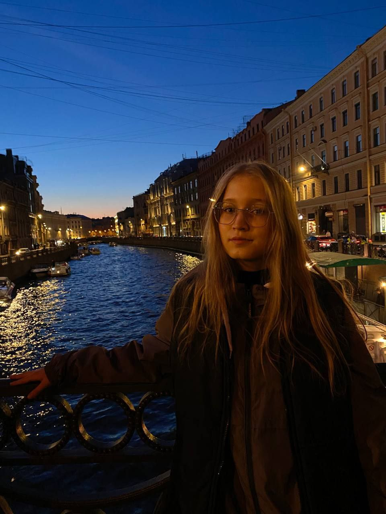

# Вводная часть

## Актуальность

- сетевые угрозы стали повседневной реальностью;
- пользователи часто доверяют небезопасным соединениям;
- базовые знания о защите данных нужны даже без технической специализации.

## Цель

Показать основные механизмы сетевой защиты и разобрать, как они работают на примере заданий курса.

## Что было изучено

- модель TCP/IP и прикладные протоколы;
- различия HTTP и HTTPS;
- cookies, сессии и персонализация;
- принципы работы TOR;
- основы защиты Wi‑Fi-сетей.

# Основная часть: ключевые задания 1 блока

## Как работает интернет: базовые сетевые протоколы

### 1

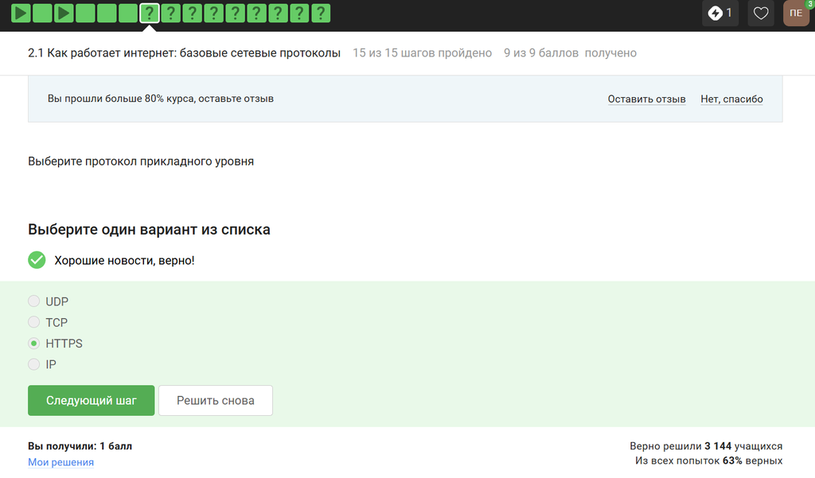

Рисунок 1: Вопрос 1

### 2

Протокол TCP - Transmission Control Protocol, он работает на транспортном уровне.

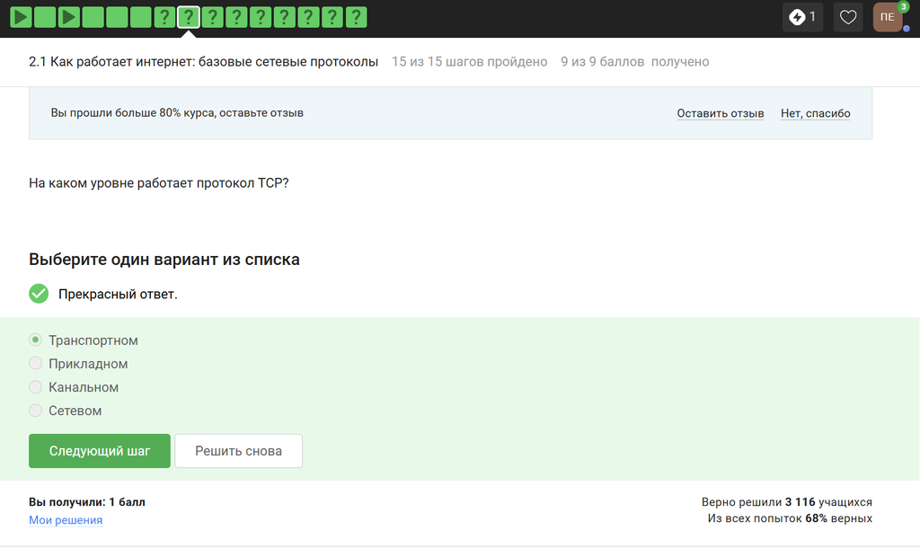

Рисунок 2: Вопрос 2

### 4

DNS - Domain Name Server - приложение, предназначенное для ответов на DNS-запросы по соответствующему протоколу.

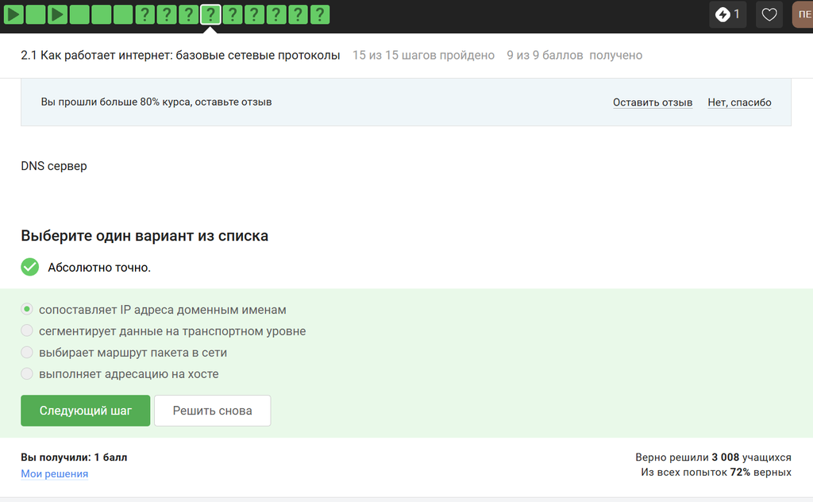

Рисунок 3: Вопрос 4

### 6

Протокол http передаёт незашифрованные данные, а протокол https уже будет передавать их в зашифрованном виде.

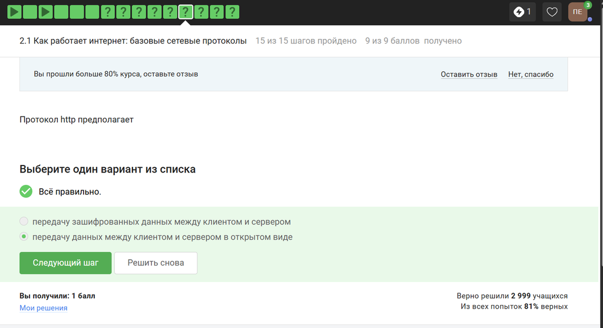

Рисунок 4: Вопрос 6

### 8

TLS определяется и клиентом, и сервером, чтобы было возможно подключиться.

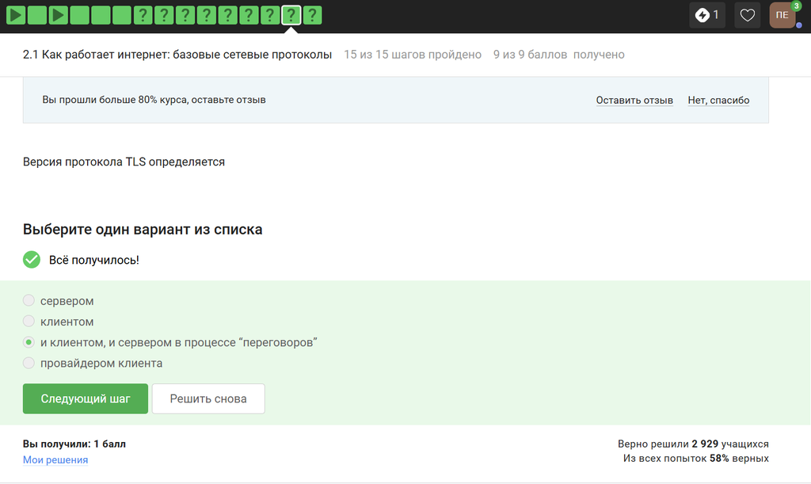

Рисунок 5: Вопрос 8

### 10

Куки точно не хранят пароли и IP-адреса, а ID сессии и идентификатор хранят.

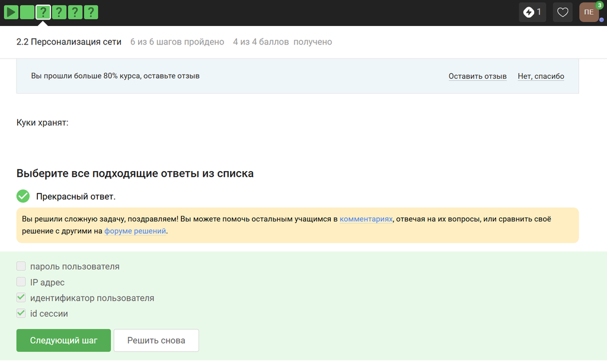

Рисунок 6: Вопрос 10

### 12

Ответ представлен на изображении.

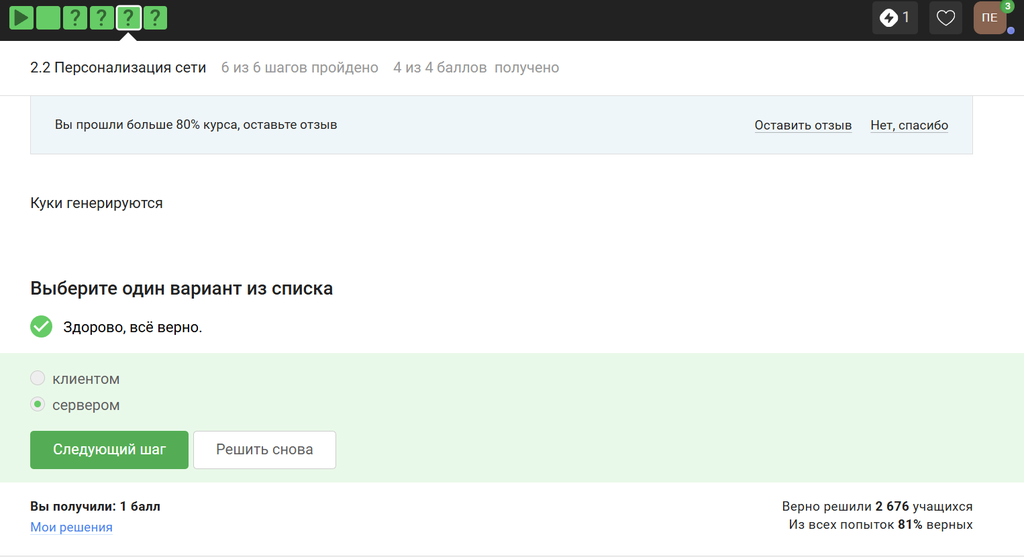

Рисунок 7: Вопрос 12

### 14

Необходимо три узла - входной, промежуточный и выходной.

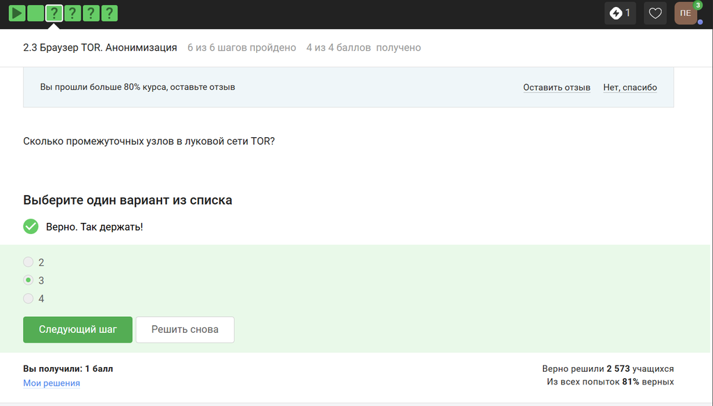

Рисунок 8: Вопрос 14

### 16

Отправитель генерирует общий секретный ключ с узлами, через которые идёт передача, то есть со всеми перечисленными.

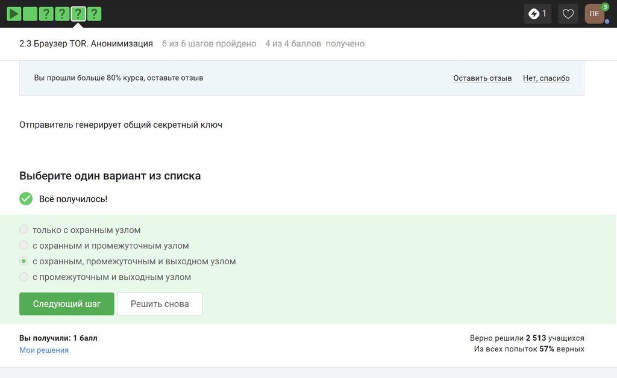

Рисунок 9: Вопрос 16

## Беспроводные сети Wi‑Fi

### 18

Выбранное определение наиболее точно.

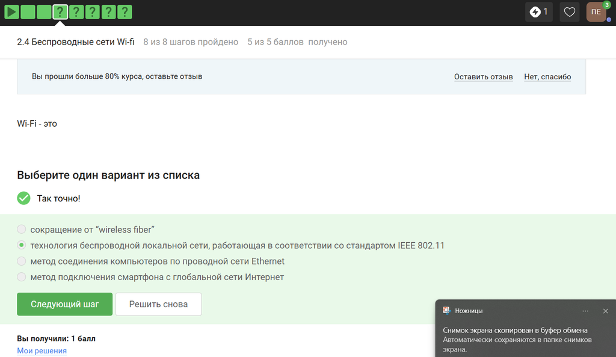

Рисунок 10: Вопрос 18

### 20

WEP (Wired Equivalent Privacy) - устаревший и небезопасный метод проверки подлинности.

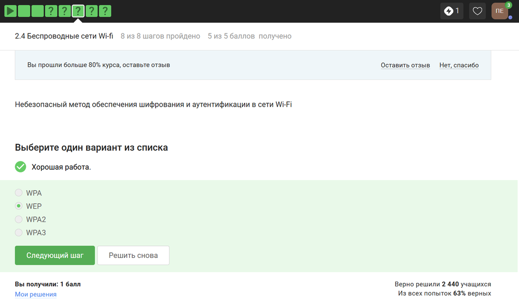

Рисунок 11: Вопрос 20

### 22

WPA2 Personal предназначен для личного использования, то есть для домашней сети, Enterprise - для предприятий.

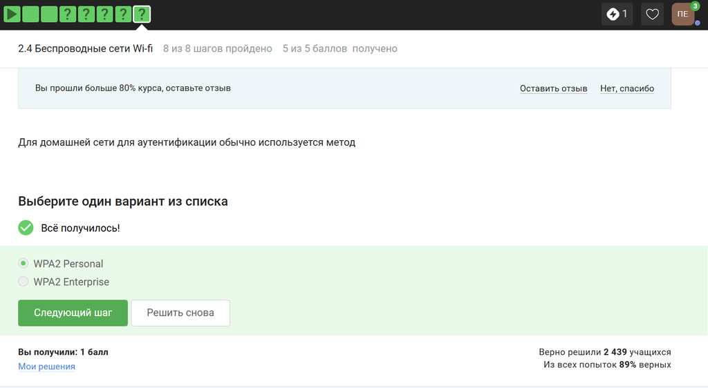

Рисунок 12: Вопрос 22

# Итоги

## Ключевые выводы

- интернет работает через набор уровней и протоколов, а не через один «магический» канал;
- HTTPS и TLS важны, потому что защищают передачу данных;
- cookies и сессии удобны, но требуют осторожности;
- TOR помогает скрывать часть сетевой информации;
- Wi‑Fi нужно настраивать с учётом безопасности, а не только удобства.

## Вывод

Первый блок курса даёт понятную опору для дальнейшего изучения кибербезопасности и помогает увидеть, где пользователь чаще всего ошибается на практике.